### Data Cleaning And Visualization

# GDP

The dataset (https://drive.google.com/file/d/1h-_Vykiu8qOej8qrhsKrIuSk88E4_C9P/) is downloaded and imported into Python through a NumPy array or Pandas data frame.

1)There are some missing values in the ‘Population’ column. Will Populate these missing values with the correct values in Python (not copy-paste) from the ‘Population.csv’ file (https://drive.google.com/file/d/1RViH13AHyAvw4datdgjdm4v2JgTa5C51/).

2)After the data is cleaned and structured in NumPy or Pandas, will need to create a new ‘GDP Per Capita’ column and populate it with the correct values, which are calculated based on the table’s Population and GDP values.

3)The data is now cleaned, structured and ready to be graphed. Using matplotlib, will create a graph that meets the following requirements: 3.1) Descriptive title above the graph 3.2) X-Axis (GDP per capita) has a label 3.3) Y-Axis (Life Expectancy) has a label 3.4) GDP per Capita and Life Expectancy data is graphed as a scatter plot 3.5) Scatter plot points are sized based on the country’s population (a larger population warrants a larger point size) 3.6) Scatter plot points are labelled by Country)

```python
# importing libariries

# pandas
import pandas as pd

# numpy
import numpy as np

# finding mean (average) of rental rates
#import statistics as stat

# matplotlib library for visualization
import matplotlib.pyplot as plt

#import seaborn library for visualization
import seaborn as sns
#%matplotlib inline
```

```python
# loading datasets
dfGdp = pd.read_csv('GDP-Life Expectancy.csv');
dfPopulation = pd.read_csv('Population.csv');
```

```python
# viewing dataset
dfGdp.head()
```

|  | Country | PPP Adjusted GDP | Population | Life Expectancy |
| --- | --- | --- | --- | --- |
| 0 | Australia | 1.356210e+12 | NaN | 82.748780 |
| 1 | Belgium | 6.305280e+11 | 1.148406e+07 | 81.595122 |
| 2 | Brazil | 3.229060e+12 | 2.110495e+08 | 75.672000 |
| 3 | Canada | 1.929900e+12 | 3.758926e+07 | 81.948780 |
| 4 | China | 2.352340e+13 | 1.397715e+09 | 76.704000 |

```python
# coulumns and rows
dfGdp.shape
```

```
(25, 4)
```

```python
# description of dataset
dfGdp.describe()
```

|  | PPP Adjusted GDP | Population | Life Expectancy |
| --- | --- | --- | --- |
| count | 2.500000e+01 | 1.900000e+01 | 25.000000 |
| mean | 4.218853e+12 | 2.406372e+08 | 78.147835 |
| std | 5.830986e+12 | 4.123180e+08 | 6.486860 |
| min | 5.741330e+11 | 8.574830e+06 | 54.332000 |
| 25% | 1.342170e+12 | 4.252382e+07 | 75.672000 |
| 50% | 2.347250e+12 | 6.705989e+07 | 80.892683 |
| 75% | 3.338140e+12 | 2.060066e+08 | 82.626829 |
| max | 2.352340e+13 | 1.397715e+09 | 84.210976 |

```python
dfGdp.info()
```

```
<class 'pandas.core.frame.DataFrame'>
RangeIndex: 25 entries, 0 to 24
Data columns (total 4 columns):
 #   Column            Non-Null Count  Dtype
---  ------            --------------  -----
 0   Country           25 non-null     object
 1   PPP Adjusted GDP  25 non-null     float64
 2   Population        19 non-null     float64
 3   Life Expectancy   25 non-null     float64
dtypes: float64(3), object(1)
memory usage: 928.0+ bytes
```

```python
dfGdp.columns
```

```
Index(['Country', 'PPP Adjusted GDP', 'Population', 'Life Expectancy'], dtype='object')
```

1)There are some missing values in the ‘Population’ column will populate these missing values with the correct values in Python (not copy-paste) from the ‘Population.csv’ file (https://drive.google.com/file/d/1RViH13AHyAvw4datdgjdm4v2JgTa5C51/).

the population has 6 missing values so we need to fill it from population csv file

```python
dfPopulation.head()
```

|  | CountryName | Country Code | Indicator Name | Indicator Code | 1960 | 1961 | 1962 | 1963 | 1964 | 1965 | ... | 2010 | 2011 | 2012 | 2013 | 2014 | 2015 | 2016 | 2017 | 2018 | 2019 |
| --- | --- | --- | --- | --- | --- | --- | --- | --- | --- | --- | --- | --- | --- | --- | --- | --- | --- | --- | --- | --- | --- |
| 0 | Aruba | ABW | Population total | SP.POP.TOTL | 54211.0 | 55438.0 | 56225.0 | 56695.0 | 57032.0 | 57360.0 | ... | 101669.0 | 102046.0 | 102560.0 | 103159.0 | 103774.0 | 104341.0 | 104872.0 | 105366.0 | 105845.0 | 106314.0 |
| 1 | Afghanistan | AFG | Population total | SP.POP.TOTL | 8996973.0 | 9169410.0 | 9351441.0 | 9543205.0 | 9744781.0 | 9956320.0 | ... | 29185507.0 | 30117413.0 | 31161376.0 | 32269589.0 | 33370794.0 | 34413603.0 | 35383128.0 | 36296400.0 | 37172386.0 | 38041754.0 |
| 2 | Angola | AGO | Population total | SP.POP.TOTL | 5454933.0 | 5531472.0 | 5608539.0 | 5679458.0 | 5735044.0 | 5770570.0 | ... | 23356246.0 | 24220661.0 | 25107931.0 | 26015780.0 | 26941779.0 | 27884381.0 | 28842484.0 | 29816748.0 | 30809762.0 | 31825295.0 |
| 3 | Albania | ALB | Population total | SP.POP.TOTL | 1608800.0 | 1659800.0 | 1711319.0 | 1762621.0 | 1814135.0 | 1864791.0 | ... | 2913021.0 | 2905195.0 | 2900401.0 | 2895092.0 | 2889104.0 | 2880703.0 | 2876101.0 | 2873457.0 | 2866376.0 | 2854191.0 |
| 4 | Andorra | AND | Population total | SP.POP.TOTL | 13411.0 | 14375.0 | 15370.0 | 16412.0 | 17469.0 | 18549.0 | ... | 84449.0 | 83747.0 | 82427.0 | 80774.0 | 79213.0 | 78011.0 | 77297.0 | 77001.0 | 77006.0 | 77142.0 |

5 rows × 64 columns

```python
dfPopulation.columns
```

```
Index(['CountryName', 'Country Code', 'Indicator Name', 'Indicator Code',
       '1960', '1961', '1962', '1963', '1964', '1965', '1966', '1967', '1968',
       '1969', '1970', '1971', '1972', '1973', '1974', '1975', '1976', '1977',
       '1978', '1979', '1980', '1981', '1982', '1983', '1984', '1985', '1986',
       '1987', '1988', '1989', '1990', '1991', '1992', '1993', '1994', '1995',
       '1996', '1997', '1998', '1999', '2000', '2001', '2002', '2003', '2004',
       '2005', '2006', '2007', '2008', '2009', '2010', '2011', '2012', '2013',
       '2014', '2015', '2016', '2017', '2018', '2019'],
      dtype='object')
```

```python
# finding nan values in GDP - Live Expectancy

nanValues=dfGdp[dfGdp.isnull().any(axis=1)]
nanValues
```

|  | Country | PPP Adjusted GDP | Population | Life Expectancy |
| --- | --- | --- | --- | --- |
| 0 | Australia | 1.356210e+12 | NaN | 82.748780 |
| 6 | Germany | 4.678570e+12 | NaN | 80.892683 |
| 12 | Netherlands | 1.032240e+12 | NaN | 81.812195 |
| 16 | Saudi Arabia | 1.680540e+12 | NaN | 74.998000 |
| 21 | Thailand | 1.342170e+12 | NaN | 76.931000 |
| 22 | Turkey | 2.347250e+12 | NaN | 77.437000 |

```python
# finding countries that have nan values in GDP - Live Expectancy table
nanValues.Country
```

```
0        Australia
6          Germany
12     Netherlands
16    Saudi Arabia
21        Thailand
22          Turkey
Name: Country, dtype: object
```

```python
# separating countries in "POPULATION table" that have NAN values in "Population field" from GDP
df_population_missing_values = dfPopulation[dfPopulation['CountryName'].isin(nanValues.Country)]

# separating only country and population field from above data frame
df_population_missing_values = pd.DataFrame(
    {'Country' : df_population_missing_values['CountryName'], 'Population' : df_population_missing_values['2019']})
df_population_missing_values
```

|  | Country | Population |
| --- | --- | --- |
| 11 | Australia | 25364307.0 |
| 53 | Germany | 83132799.0 |
| 174 | Netherlands | 17332850.0 |
| 203 | Saudi Arabia | 34268528.0 |
| 231 | Thailand | 69625582.0 |
| 242 | Turkey | 83429615.0 |

```python
df_population_missing_values['Population']
```

```
11     25364307.0
53     83132799.0
174    17332850.0
203    34268528.0
231    69625582.0
242    83429615.0
Name: Population, dtype: float64
```

```python
#You can set Country as index for both dataframes, and then use
#the fillna() method, which fill missing values, while matching the index of the two dataframes:

#filling NAN values in GDP table with the values in Population table
dfGdp = dfGdp.set_index("Country").fillna(df_population_missing_values.set_index("Country")).reset_index()
```

### Data Preprocessing

Step 1 : sanity check

```python
# info
dfGdp.info()
```

```
<class 'pandas.core.frame.DataFrame'>
RangeIndex: 25 entries, 0 to 24
Data columns (total 4 columns):
 #   Column            Non-Null Count  Dtype
---  ------            --------------  -----
 0   Country           25 non-null     object
 1   PPP Adjusted GDP  25 non-null     float64
 2   Population        25 non-null     float64
 3   Life Expectancy   25 non-null     float64
dtypes: float64(3), object(1)
memory usage: 928.0+ bytes
```

#### missing values has been treated

```python
# check duplicate values
dfGdp.duplicated().sum()
```

```
0
```

```python
# identifying garbage values
for i in dfGdp.select_dtypes(include="object").columns:
    print(dfGdp[i].value_counts())
    print ('***' * 10)
```

```
Australia         1
Nigeria           1
United Kingdom    1
Turkey            1
Thailand          1
Switzerland       1
Sweden            1
Spain             1
South Korea       1
Saudi Arabia      1
Russia            1
Poland            1
Netherlands       1
Belgium           1
Mexico            1
Japan             1
Italy             1
Indonesia         1
India             1
Germany           1
France            1
China             1
Canada            1
Brazil            1
United States     1
Name: Country, dtype: int64
```

Step 2 : EDA

1) descriptive analysis

```python
# descriptive statistics
dfGdp.describe().T
```

|  | count | mean | std | min | 25% | 50% | 75% | max |
| --- | --- | --- | --- | --- | --- | --- | --- | --- |
| PPP Adjusted GDP | 25.0 | 4.218853e+12 | 5.830986e+12 | 5.741330e+11 | 1.342170e+12 | 2.347250e+12 | 3.338140e+12 | 2.352340e+13 |
| Population | 25.0 | 1.954104e+08 | 3.666593e+08 | 8.574830e+06 | 3.758926e+07 | 6.705989e+07 | 1.443735e+08 | 1.397715e+09 |
| Life Expectancy | 25.0 | 7.814784e+01 | 6.486860e+00 | 5.433200e+01 | 7.567200e+01 | 8.089268e+01 | 8.262683e+01 | 8.421098e+01 |

```python
dfGdp.describe(include="object")
```

|  | Country |
| --- | --- |
| count | 25 |
| unique | 25 |
| top | Australia |
| freq | 1 |

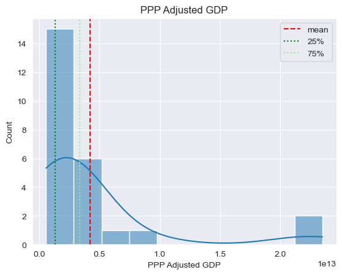

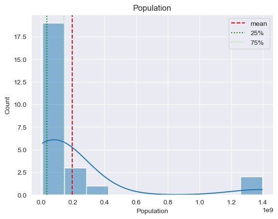

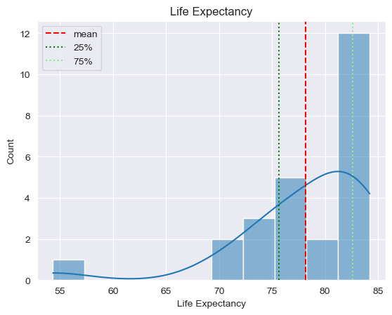

```python
# histogram to understand the distribution
sns.set_style('darkgrid')
for i in dfGdp.select_dtypes(include="number").columns:
    sns.histplot(data=dfGdp,x=i, bins=10, kde=True)
    plt.axvline(x=np.mean(dfGdp[i]),color='red',ls='dashed', label='mean')
    plt.axvline(x=np.percentile(dfGdp[i],25),color='green',ls='dotted', label='25%')
    plt.axvline(x=np.percentile(dfGdp[i],75),color='lightgreen',ls='dotted', label='75%')
    plt.title(i)
    plt.legend()
    plt.show()
```

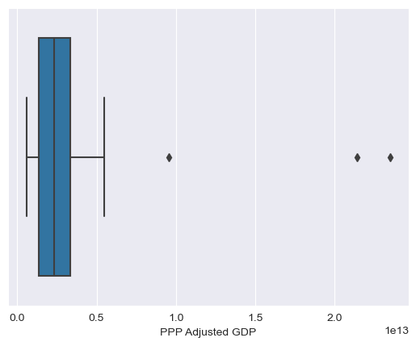

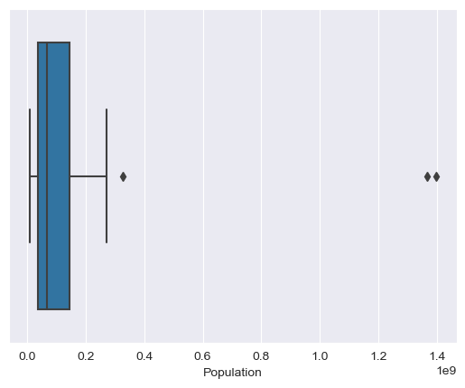

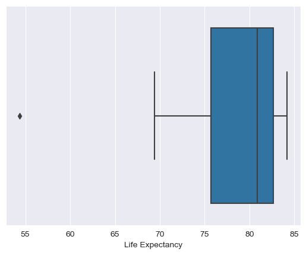

```python
# Boxplot to identify outliers

for i in dfGdp.select_dtypes(include="number").columns:
    sns.boxplot(data=dfGdp,x=i)

    plt.show()
```

2)After the data is cleaned and structured in NumPy or Pandas, will create a new ‘GDP Per Capita’ column and populate it with the correct values, which are calculated based on the table’s Population and GDP values.

GDP Per Capita = GDP of the Country / Population Of that Country

```python
dfGdp.insert(loc=len(dfGdp.columns), column = "GDP Per Capita", value =(dfGdp['PPP Adjusted GDP']/dfGdp['Population']))
```

```python
dfGdp.head()
```

|  | Country | PPP Adjusted GDP | Population | Life Expectancy | GDP Per Capita |
| --- | --- | --- | --- | --- | --- |
| 0 | Australia | 1.356210e+12 | 2.536431e+07 | 82.748780 | 53469.231389 |
| 1 | Belgium | 6.305280e+11 | 1.148406e+07 | 81.595122 | 54904.624323 |
| 2 | Brazil | 3.229060e+12 | 2.110495e+08 | 75.672000 | 15300.010381 |
| 3 | Canada | 1.929900e+12 | 3.758926e+07 | 81.948780 | 51341.792842 |
| 4 | China | 2.352340e+13 | 1.397715e+09 | 76.704000 | 16829.897368 |

3)The data is now cleaned, structured and ready to be graphed. Using matplotlib, will create a graph that meets the following requirements: 3.1)Descriptive title above the graph 3.2)X-Axis (GDP per capita) has a label 3.3)Y-Axis (Life Expectancy) has a label 3.4)GDP per Capita and Life Expectancy data is graphed as a scatter plot 3.5)Scatter plot points are sized based on the country’s population (a larger population warrants a larger point size) 3.6)Scatter plot points are labelled by Country)

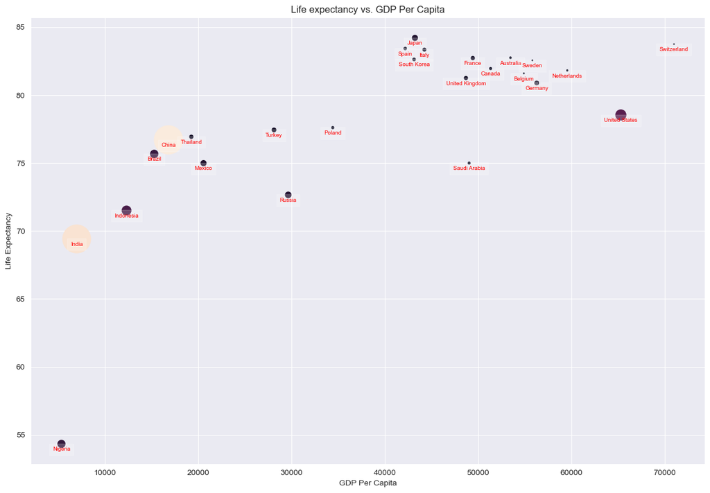

```python
x=dfGdp['GDP Per Capita']
y=dfGdp['Life Expectancy']
color = dfGdp['Population']
font={
    'color' : 'red'
}
box= {'facecolor' : 'white',
     'alpha': 0.2}
plt.figure(figsize=(15,10))
plt.scatter(x, y,s=(dfGdp['Population']/dfGdp['Population'].min())**1.4,c=color)

for i in dfGdp['Country']:
    plt.text(dfGdp['GDP Per Capita'][dfGdp['Country']==i], dfGdp['Life Expectancy'][dfGdp['Country']==i]-0.36, s=i,
             bbox=box, ha="center", va="center_baseline", fontsize='x-small', fontdict=font)

plt.title("Life expectancy vs. GDP Per Capita")
plt.xlabel('GDP Per Capita')
plt.ylabel('Life Expectancy')
plt.show()
```